# ESM 270 Ocean Health Index Lab

Julie Lowndes and Ben Halpern

June 1, 2016

# 1 Introduction

The Ocean Health Index (OHI) framework measures the health of coupled human-ocean ecosystems in different contexts by accommodating differences in local environmental characteristics, cultural priorities, and information availability and quality. The OHI framework assesses a suite of benefits the ocean provides humans - called ‘goals’ - using the best information available. It distills complex socio-ecological relationships and context-specific targets into scores that can be repeated so that management can track and respond through time.

Assessments using the OHI framework results in scores for each goal as well as in a single score for overall ocean health, which is a weighted-average of each goal’s score. Each goal’s score is calculated compared to a target called a **reference point**, and thus the score represents how close the goal is to meeting that target, on a scale from 0-100. Scores can be represented on a flower plot, where the center value is the overall OHI score. Each petal of the flower plot represents a goal; the length is the score of that particular goal and the width is its **weight**: contribution to the overall score.

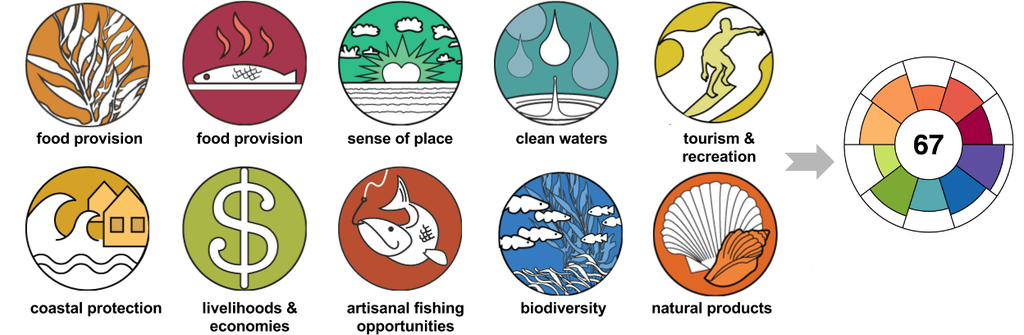

**Ocean Health Index goals can be represented as a flower plot**

# 2 Instructions

In this assignment you will explore how Ocean Health Index (OHI) scores respond when you change two things:

1. how goals are weighted
2. the reference point of a goal

You will be using the OHI Toolbox software to do this, and follow the instructions here ([`OHI_Instructions.Rmd`](https://rawgit.com/OHI-Science/ohi-global/draft/ESM_270/OHI_Instructions.html)). Walk through line-by-line and execute the code in R; the order does matter so be sure to proceed line-by-line. The example presented is for the USA, so please choose another country for your assignment.

Your final figures will be saved as .pngs within the ohi-global folder you will download.

## 2.1 Get the ohi-global repo

We’ll be playing with weights and reference points for the global OHI assessments; we calculate scores each year for 221 coastal nations and territories. Let’s get it on your computer.

1. Go to github.com/OHI-Science/ohi-global. This is the `ohi-global` repository ‘repo’.
2. Click on the green ‘clone or download’ button. (If you are familiar with GitHub, clone this repository; otherwise click ‘Download ZIP’).
3. Navigate to where you saved the repo (check the Downloads folder).
4. Make sure the folder is simply called `ohi-global`. If necessary, rename it (delete ‘-draft’ if it exists).
5. Extract the ZIP file: right click to extract using 7Zip
6. Open the folder (rename to `ohi-global` again if necessary).
7. Double-click the `ohi-global.Rproj` (if file extensions aren’t displayed this file will be simply called `ohi-global`). Double-clicking this `.Rproj` file which will open [RStudio](https://www.rstudio.com/) (which is how you should always interface with R).

## 2.2 Setup

Since we’re in RStudio with a `.Rproj` file, our current working directory is `wherever/you/saved/it/ohi-global`. All of our work for the assignment happens in the `ESM_270` folder (what you are reading is from `ohi-global/ESM_270/ESM_270_OHI.Rmd`). Let’s change the working directory to the `ESM_270` folder, and install the packages we need to get going. The `ESM_270` folder has a mix of `.R` scripts and `.csv` files that we will be using (you can navigate to them in RStudio’s lower-right files pane, but will still need to set your working directory).

**Note:** the following code assumes the the `ohicore` package is already installed on the GIS lab computers. See the full install instructions at the end of the document.

Run the following code:

```r
## set working directory to ohi-global/ESM_270
setwd('ESM_270')

## load ohicore library (ohicore is already installed). -- Warnings are OK, but make sure no errors.
library(ohicore)

## source the function to make flower plots; this won't do anything yet.
source('PlotFlowerMulti.r')
```

## 2.3 Calculate scores

We can calculate OHI scores by sourcing `calculate_scores.r` (below). This uses the following files, which are all in our current working directory, `ohi-global/ESM_270`:

- input data layers in the `layers` folder
- goal models and reference points in `conf/functions.r`
- goal weighs in `conf/goals.csv`
- calculated scores for all goals and all 221 regions are saved in `scores.csv`.

**Note:** because the Toolbox relies on these file names for calculation and for visualizing, we’ll be overwriting some of these files (after saving the originals) to use in each of the steps as we go forward.

```r
## calculate scores. The Toolbox will describe each step as it calculates
source('calculate_scores.r')

## save copies of original files
file.copy('conf/goals.csv',   'conf/goals_orig.csv', overwrite = TRUE)
file.copy('conf/functions.r', 'conf/functions_orig.r', overwrite = TRUE)
file.copy('scores.csv',       'scores_orig.csv', overwrite = TRUE)
```

## 2.4 Choose your region

We just calculated scores for all 221 regions. But you’ll just be inspecting one region, which do you choose? Each region has a unique numeric identifier. Run this to view the full list of regions and choose one to inspect: `View(read.csv('layers/rgn_global.csv'))`. Use the search bar in the top right of the View pane to find your country and note its `rgn_id`.

You’ll assign it in R now as `my_rgn`:

```r
## assign your rgn_id
my_rgn <-  163 # United States; change this to your region of choice
```

## 2.5 Original flower plot for your region

Now, let’s visualize your region’s scores in a flower plot. The `PlotFlowerMulti()` function will make figures for you, saving them as .pngs in `ohi-global/ESM_270/reports/figures` and displaying them in the RStudio Viewer (they will look a bit cut-off in the Viewer but that is just a vizualization glitch; the .pngs are fine).

Run the following – it will save a file with your region’s name, for example `ohi-global/ESM_270/reports/figures/flower_orig_United_States.png.`:

```r
## parameters for the flower plot
scores_orig <- read.csv('scores_orig.csv')
conf_orig <- read.csv('conf/goals_orig.csv')
name_fig_orig <- 'reports/figures/flower_orig'   # my_rng is appended to name_fig

## function call for the flower plot -- original
PlotFlowerMulti(scores       = scores_orig,
                rgns_to_plot = my_rgn,
                conf         = conf_orig,
                name_fig     = name_fig_orig)
```

## 2.6 Change goal weighting

Now you will change the goal weighting for one of the goals.

Refer to the Introduction above to see the list of goals. Currently, goals are weighted equally. This means goals have a weight of 1; if a goal has sub-goals, those are weighted each as 0.5. View this with `View(conf_orig %>% dplyr::select(goal, name, weight))`. Identify the 2- or 3- letter code for the goal or sub-goal you want to change.

Run the following after updating the weight; the example below shows changing the weight of the Artisanal Fishing Opportunity goal (‘AO’) to 3. Note that all of these weights are relative; so you can just change one goal weight without worrying about what it adds up to. This will save a file with your region’s name, for example `ohi-global/ESM_270/reports/figures/flower_weights_new_United_States.png.`

```r
## create a new variable conf_new_wt
conf_new_wt <- conf_orig

## change the weight of a goal, eg AO to 3 and save file
conf_new_wt$weight[conf_new_wt$goal == 'AO'] = 3. # the 2- or 3- letter code must be in quotes.
write.csv(conf_new_wt, 'conf/goals.csv', row.names = FALSE)

## re-calculate scores with new weight
source('calculate_scores.r')
scores_new_wt <- read.csv('scores.csv')

## parameter for the flower plot -- new weight
name_fig_weights <- 'reports/figures/flower_weights_new'

## function call for the flower plot
PlotFlowerMulti(scores       = scores_new_wt,
                rgns_to_plot = my_rgn,
                conf         = conf_new_wt,
                name_fig     = name_fig_weights)
```

## 2.7 Change reference point

The **Lasting Special Places** sub-goal represents geographic locations that hold particular value for aesthetic, spiritual, cultural, recreational or existence reasons, and assesses how well they are protected. In global assessments, we model this with the proportion of the offshore area that is a marine protected area (MPAs), with the reference point set to 30%.

You can see this by navigating to `conf/functions.r`, and looking at line 1484: you can also search for `LSP =`. Right now it’s set to 30% of waters should be in MPAs. What if we altered that? The example below changes it to 40%.

Go ahead and change it and run the following. It will save a file with your region’s name, for example `ohi-global/ESM_270/reports/figures/flower_ref_new_United_States.png.`

```r
## set a new reference point
ref_pct_new <- 40 # change this with your reference point

## run this to insert your new reference point into conf/functions.r If problems, you can change this one by hand in functions.r
readLines('conf/functions.r') %>%
  stringr::str_replace("LSP = .*", sprintf("LSP = function(layers, ref_pct_cmpa=%s, ref_pct_cp=%s, status_year){",
                                  ref_pct_new, ref_pct_new)) %>%
  writeLines('conf/functions.r')

## reset original conf/goals.csv file
write.csv(conf_orig, 'conf/goals.csv', row.names = FALSE) # use original conf

## re-calculate scores with new reference point
source('calculate_scores.r')
scores_new_ref <- read.csv('scores.csv')

## parameter for the flower plot -- new reference point
name_fig_ref <- 'reports/figures/flower_ref_new'

PlotFlowerMulti(scores       = scores_new_ref,
                rgns_to_plot = my_rgn,
                conf         = conf_orig,
                name_fig     = name_fig_ref)
```

## 2.8 Inspect scores more closely

How does the new reference point flower plot compare with the original? How much would you have expected the overall score to change? And how would you communicate this using the flower plots?

Run this to compare how much the LSP goal score changed vs. the overall Index score (displayed in the middle of the flower plot):

```r
## investigate the LSP scores:
scores_orig %>%
  dplyr::filter(region_id == my_rgn,
         goal == 'LSP',
         dimension == 'score')

scores_new_ref %>%
  dplyr::filter(region_id == my_rgn,
         goal == 'LSP',
         dimension == 'score')

## investigate the overall Index scores
scores_orig %>%
  dplyr::filter(region_id == my_rgn,
         goal == 'Index',
         dimension == 'score')

scores_new_ref %>%
  dplyr::filter(region_id == my_rgn,
         goal == 'Index',
         dimension == 'score')
```

# 3 Full ohicore install instructions

The OHI R package `ohicore` is already installed on the GIS lab computers, so if you are working there, you can ignore this.

But if you’re working on your on machine, run the following to install `ohicore`, and then continue with the Setup instructions from the lab (above) and carry on.

```r
## delete any existing version of `ohicore`
for (p in c('ohicore')){
  if (p %in% rownames(installed.packages())){
    lib = subset(as.data.frame(installed.packages()), Package==p, LibPath, drop=T)
    remove.packages(p, lib)
  }
}

## install dependencies
for (p in c('devtools', 'git2r')){
  if (!require(p, character.only=T)){
    install.packages(p)
    require(p, character.only=T)
  }
}

## install most current version of ohicore -- don't worry about the warnings. But make sure there are no errors.
devtools::install_github('ohi-science/ohicore@dev')
```